# Assignment 1: RMarkdown Practice

Jake Barrett

8/25/2021

**Because I’ve only just begun collecting data, I’m utilizing some randomly generated data that I’ve used previously to perform some statistical tests that I’ll eventually use to analyze my collected data.**

Below is a figure resulting from a principal component analysis analyzing relationships between the (randomly generated) personality traits. As you can see, personality variation isn’t reaily explained by colonization status.

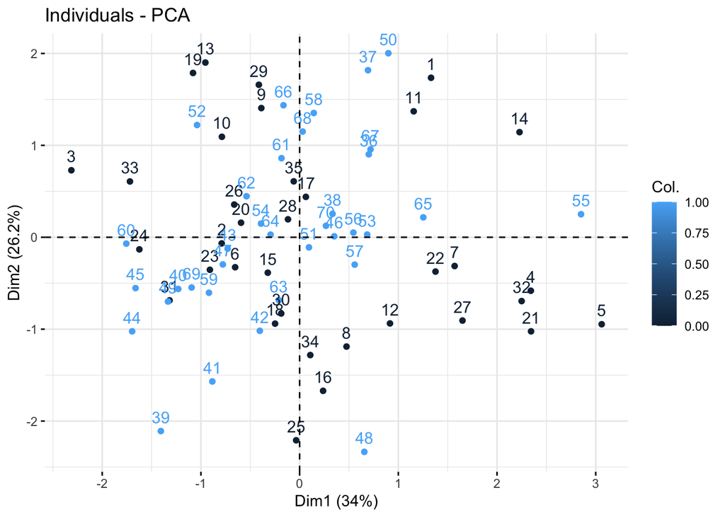

Similarly, this figure presents the relative contributions of each variable to the resulting principal components.

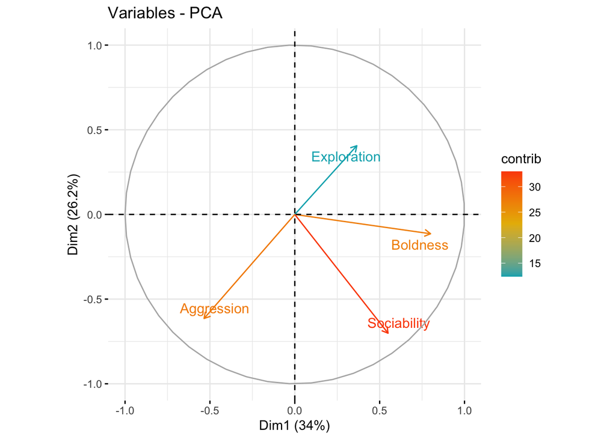

Here, I’ve tested the relationship between length and boldness using a generalized linear model. With a p-value = 0.36, there is no evidence for relationship between length and boldness for this species.

```r
personality <- read.csv("personalitydata_generated.csv")
p1 <- glm(Boldness ~ Length,
          data = personality,
          family = gaussian(link = "identity"))
summary(p1)
```

```
##
## Call:
## glm(formula = Boldness ~ Length, family = gaussian(link = "identity"),
##     data = personality)
##
## Deviance Residuals:
##     Min       1Q   Median       3Q      Max
## -14.499  -10.495   -4.388    6.680   31.769
##
## Coefficients:
##             Estimate Std. Error t value Pr(>|t|)
## (Intercept) 21.01920    6.96866   3.016   0.0036 **
## Length      -0.06470    0.07007  -0.923   0.3591
## ---
## Signif. codes:  0 '***' 0.001 '**' 0.01 '*' 0.05 '.' 0.1 ' ' 1
##
## (Dispersion parameter for gaussian family taken to be 172.1447)
##
##     Null deviance: 11853  on 69  degrees of freedom
## Residual deviance: 11706  on 68  degrees of freedom
## AIC: 563.01
##
## Number of Fisher Scoring iterations: 2
```

Now, pictured below is a table presenting the mean and standard deviation for each personality trait, grouped by sex (where 0 = male and 1 = female.

Table 2. A summary kable displaying number, mean, and standard deviation for each personality score, grouped by sex (where 0 = male and 1 = female

| Sex | n | Mean.Bold | SD.Bold | Mean.Soc | SD.Soc | Mean.Exp | SD.Exp | Mean.Agg | SD.Agg |
| --- | --- | --- | --- | --- | --- | --- | --- | --- | --- |
| 0 | 34 | 15.53735 | 12.46924 | 5.762059 | 2.226520 | 43.95265 | 22.55817 | 4.500000 | 2.631395 |
| 1 | 36 | 14.00639 | 13.81584 | 5.522778 | 2.139994 | 40.81083 | 22.35723 | 3.916667 | 3.017804 |

Below is a summary table of mean and standard deviation for each personality trait, grouped by colonization status (where 0 = resident and 1 = recent colonizer)

Table 2. A summary kable displaying number, mean, and standard deviation for each personality score, grouped by colonization status (where 0 = resident and 1 = recent colonizer

| Colonizer.Status | n | Mean.Bold | SD.Bold | Mean.Soc | SD.Soc | Mean.Exp | SD.Exp | Mean.Agg | SD.Agg |
| --- | --- | --- | --- | --- | --- | --- | --- | --- | --- |
| 0 | 35 | 17.67314 | 15.40903 | 5.672571 | 2.652394 | 35.42257 | 24.72083 | 3.542857 | 1.915001 |
| 1 | 35 | 11.82686 | 9.67344 | 5.605429 | 1.586753 | 49.25114 | 17.43507 | 4.857143 | 3.422614 |

Here is a map of the location of one of my study sites, Dry Fork Creek in Montgomery County.

[interactive chart not shown]

Embedded below is a video of a Creek Chub building a spawning nest - neat!

[video not shown]

This kid caught a 9.5 oz. Creek Chub - a Nebraska state record!

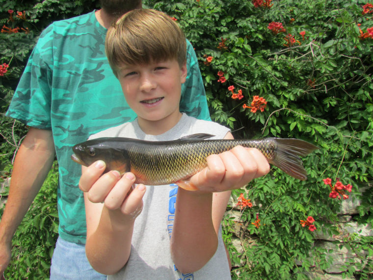

*Thank you and stay classy, Clarksville!*